# Data Exploration

Amitav Sahay

October 2, 2018

# Milestone Report: Data Exploration

## Project Background

1. The goal for this project is to be able to predict for each IPL20 cricket match: a) the match winner, and b) approximate runs the two teams will score in the match. The prediction will happen while a match is in progress, at the end of specific overs: for final score of each team, the prediction will be at the end of 6th over (= end of powerplay), and at the end of 10th and 15th overs respctively of each team’s batting. Each match winner will be predicted right at the start of the match after the toss, then at the end of Innings 1 before the 2nd team starts its batting, and then at the end of the 26th over, 30th over and 35th overs of the match (which are the same as at the end of 6th, 10th and 15th over of the 2nd innings). So while it may be tempting to explore if such milestones have an impact on the prediction, like in which over does a team reaches its 50th or 100th run, or does it matter how soon a team loses its first 4 or 5 batsmen (typically your frontline batsmen), I cannot consider these parameters directly since we dont know beforehand in which over these may happen. So instead I will explore parameters relevant at the start of the match, and then at the end of the specific overs mentioned above. I have to remember that since the predictions are for a live match, the training data needs to be explored in that context: when I predict at the end of the 6th over, I will explore data only till the 6th over of innings of previous matches for independent variables; when prediction happens at the end of 10th over, I wil explore data up till the end of 10th over of previous matches. For the 2 dependent variables mentioned above, the independent variables that spring to mind are:
1. Winner of the most recent previous match between the two teams playing this current match (*who is playng who*)
2. Who has won how many times in their most recent last 3 encounters, and in the last 5 encounters (assuming the team with recent wins agains the same oppostion has an edge in the current ongoing match)
3. where the current match is being played: some teams perform better at certain venues, and also the ground conditions at certain venues may be more amenable to batting, and at some other venues to bowling, meaning teams are likley to post a higher socre in the 1st scenario and a lower score in the 2nd scenario than the average scores ( so *who is playing, and where*)
4. Does the psychological advantage of winning the toss at the start of a match (to elect if you want to bat first or bat second) translate to a significant probability of winning the match
5. Similarly, regardless of winning the toss, does the data show if it is advantageous to bat first or to bowl first, or it does not matter
6. runs scored at the end of various overs; the thought being that the prediction will be better deep into a team’s batting innings: the higher the number of overs batted, the more accurate the final score prediction
7. Impact of how many runs were scored and how many wickets were lost in the initial overs: 1st 4 overs, 1st 6 overs, 1st 8 overs and 1st 10 overs (half way mark) of each innings. The hypothesis is that if a team loses early wickets, it may not score that many runs by the end, and also if it scores slowly in the beginning (fewer runs in the initial overs), it may be difficult to post a big total at the end of its innings (EOI).

### Caveat

I am ignoring the effects of current weather conditions or if a match is the finals of aseason’s tournament, both of which can deviate scores from the norm. I am also ignoring matches that were shortened (< 12 overs each) either due to weather or due to a team collapsing thereby having a quick match decision.

## Feature Engineering:

Data exploration is performed on a wrangled data file, read into R as a data frame: each row represents relevant details of each match. The data files are in my github folder: https://github.com/asahay001/springboardIntro File name: wrangled_matchSummaryDataIPL.csv

1. New columns created for data exploration and liner regression models:
   - Does the team batting first win the match: True/False
   - Summary Scenarios at end of each over, 1 through the end of each innings
   - Matches won by each team in the data set
   - Win Percentage of each team (Matches Won / Matches Played) in the dataset
   - Result of prior matches between two teams: who won the most recent previous match, last 3, and last 5
2. Ball-by-ball detail rows were summarized into columns, since score prediction is at end of overs. This resulted in 150370 detail, ball-by-ball rows in the 2008-2017 dataset to be summarized to 609 rows.

## Data Exploration

Have used two approaches to understand the IPL data: a) Correlation among various independent and dependent variables b) Plots of variables to see if trends exist

### Correlations among variables

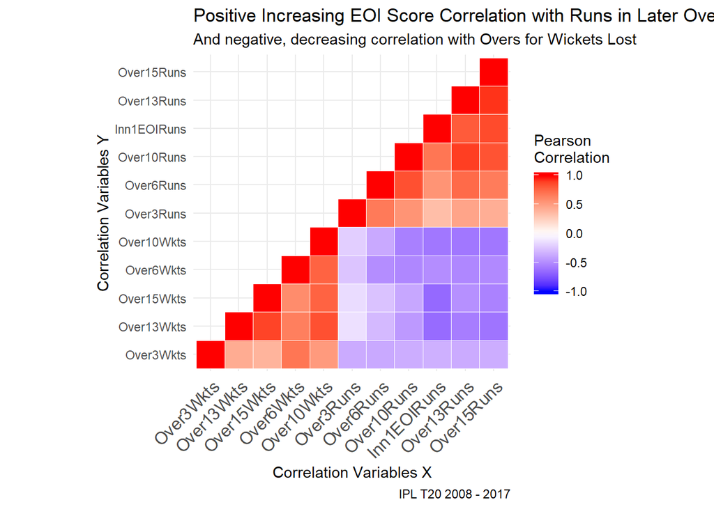

2. Next, checking the correlation between a team winning a current match with matches won against that same opponent recently, shows that the *last match result is not as consequential as a winning streak against the same opponent over the last 5 matches*. Lso, correlation between a) a team batting first winning its current match, b) its wining percentage record against all teams, c) and the winning percentage record of its opponent (the team that will bat second in this match), shows *a weak correlation with the past records*, again indicating that each match is decided on how well the team plays on that given day.

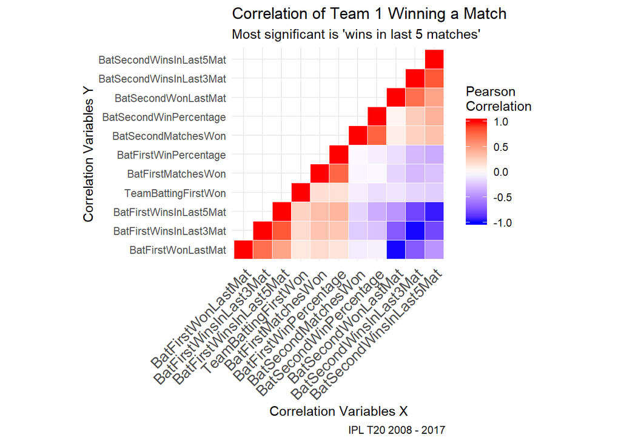

## Plotting variations and covariations in variables

I have saved the plots in plots.pdf file in the following github directory: https://github.com/asahay001/springboardIntro. The R file to produce the plots is called dataExploreMatchScorePrediction.R

1. First, let’s explore *variation within* the 2 *dependent variables*, one at a time:
   1. match winners, and
   2. runs scored in each innings
1. Match Winners:

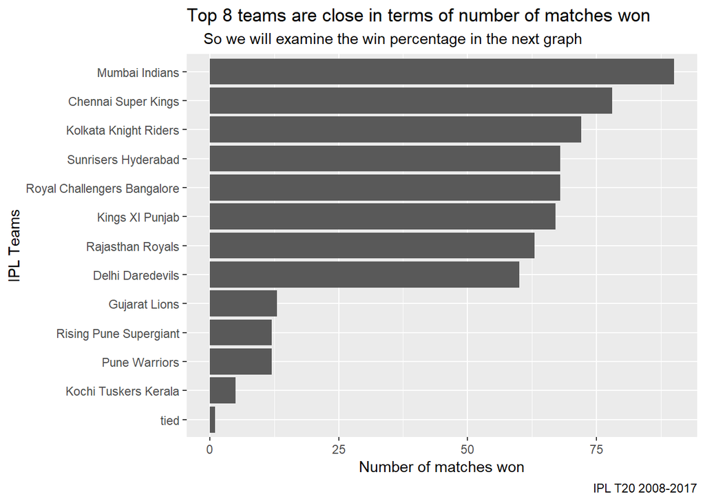

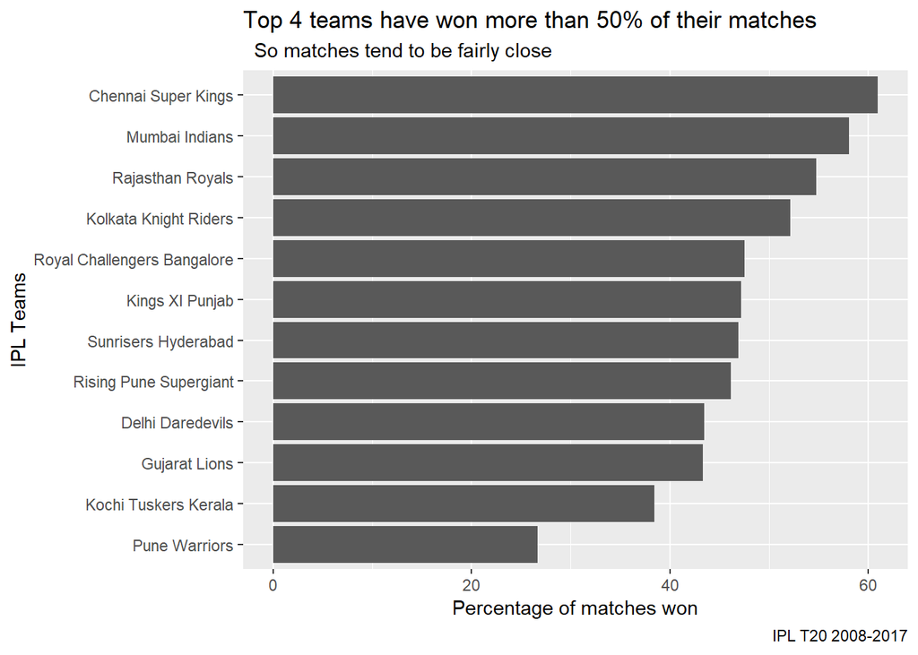

These plots show that many teams are clustered together in terms of their winning Percentage record; the top 8 teams have a 45+ percentage record of winning, and so picking a winner based solely on past record may not be possible.

2. Runs scored (also called End Of Innings Score):

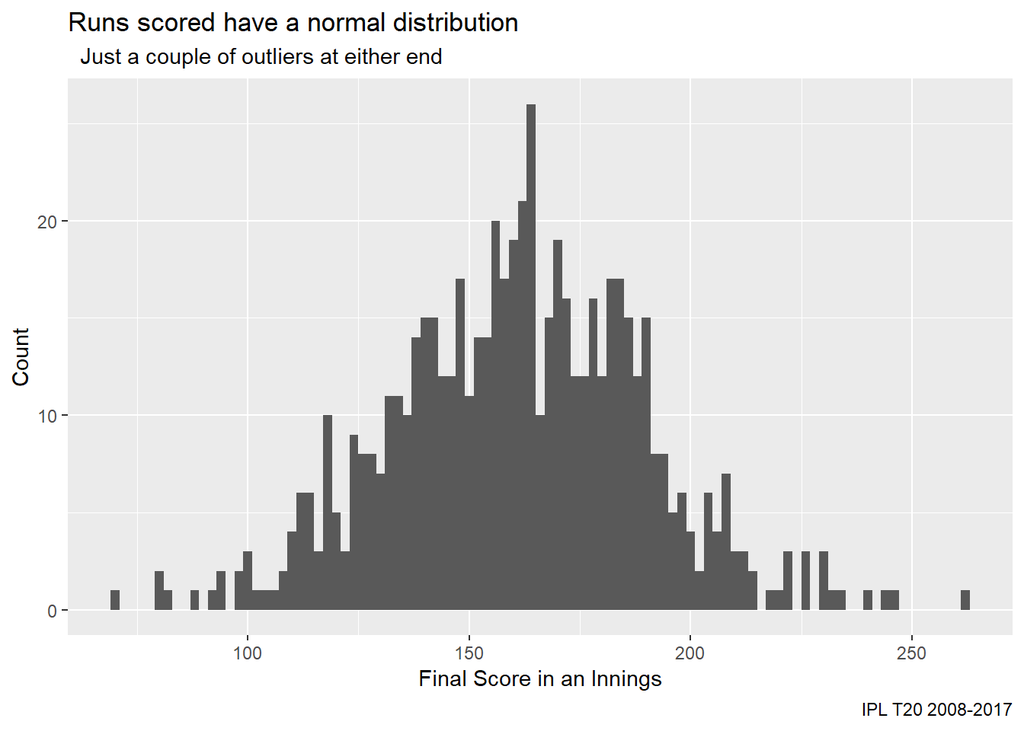

2. Next look at the *covariations between variables*, from two perspectives:
1. At the start of the match before a ball is bowled
2. During the match as overs progress, runs are scored, and wickets are lost
3. At the start of match, let’s examine if the match winner is significantly dependent on:
   1. the venue where the match is being played,
   2. the psychological advantage of winning the toss and electing to bat first or second in the match,
   3. past results

   Effect of Venue / ground on final score:

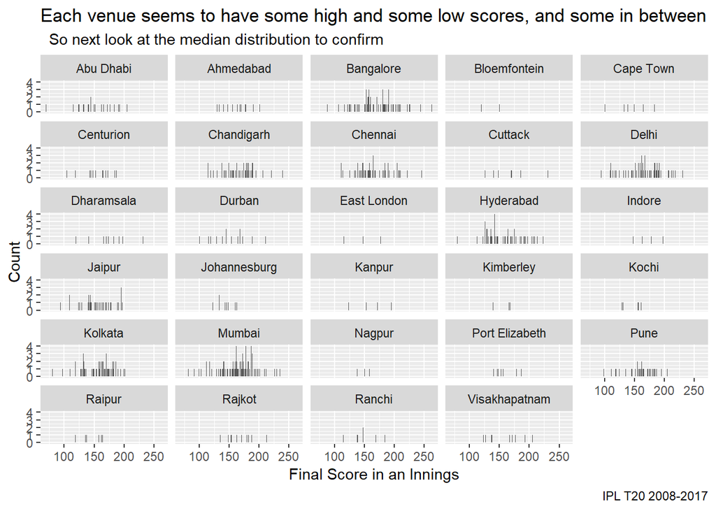

[figure not shown]

Effect of Toss on ultimately winning the match:

[figure not shown]

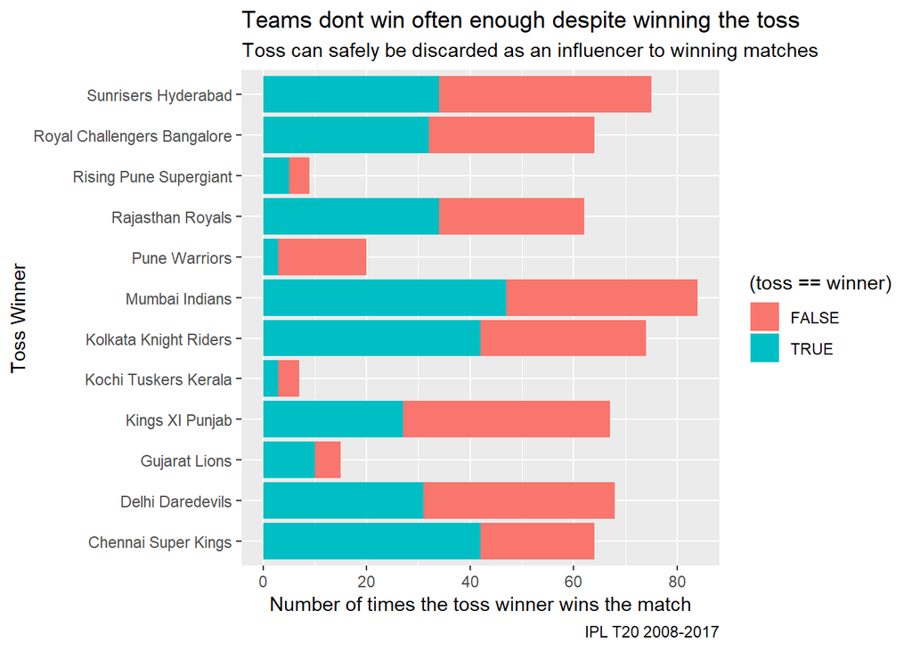

Significance of Past match Results between today’s two teams:

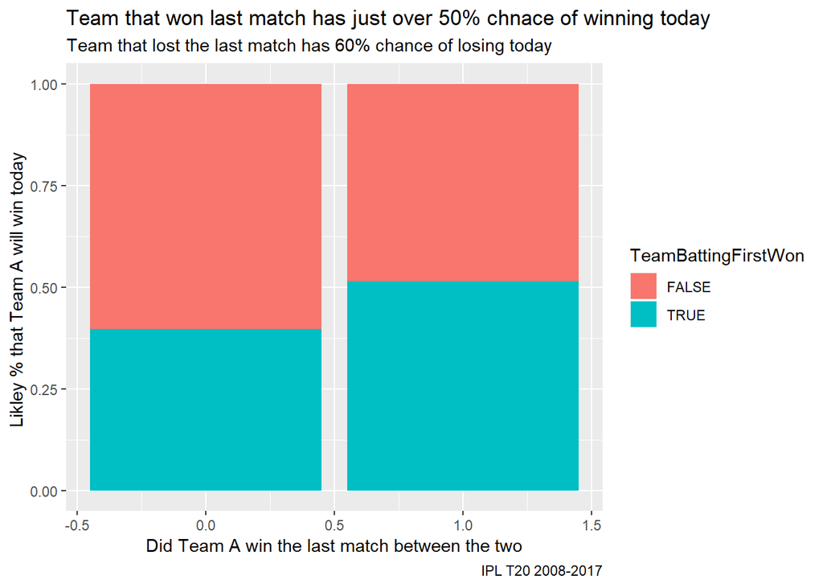

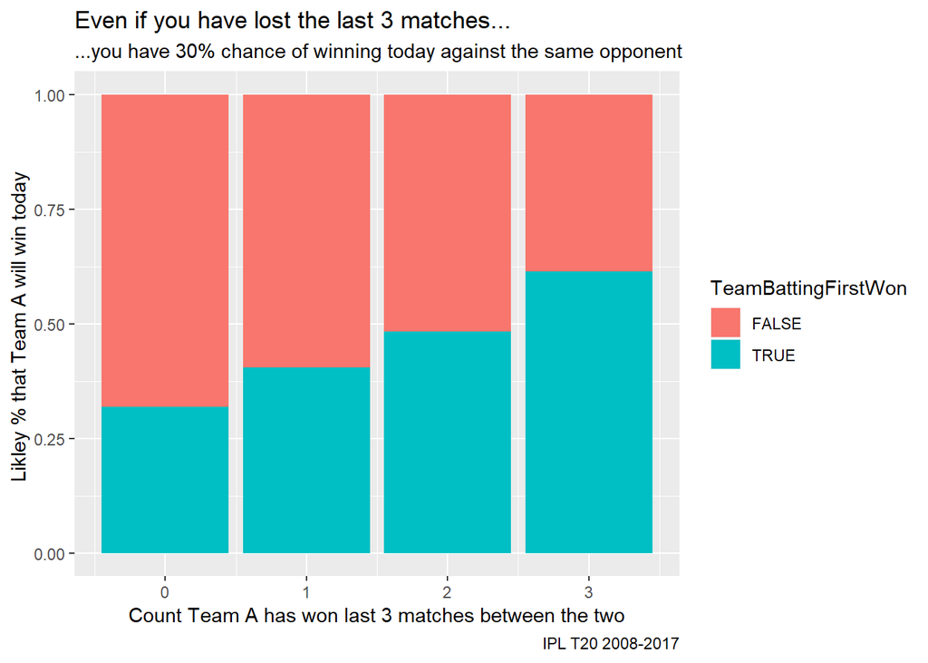

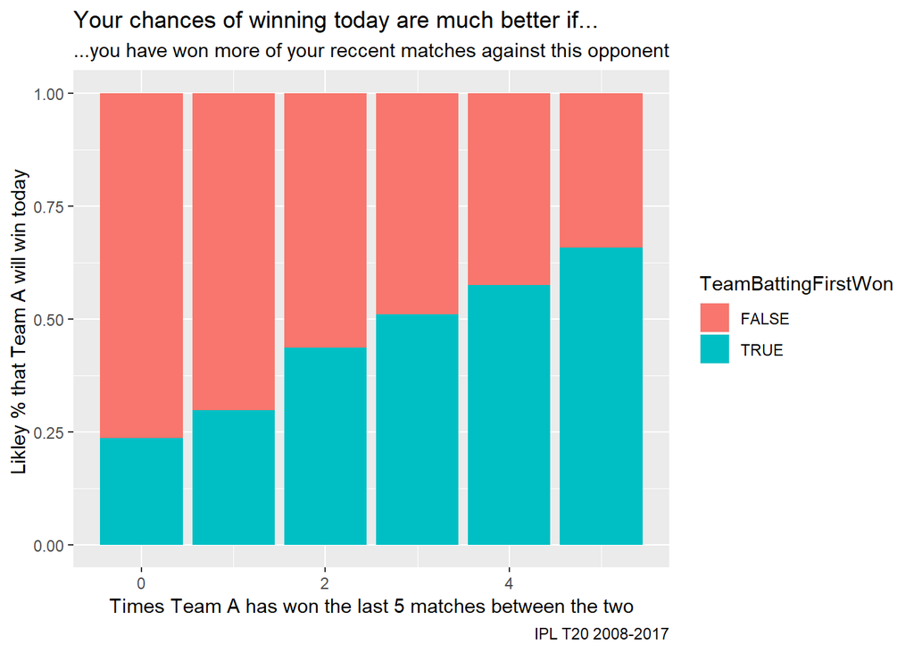

Let’s also examine what are the odds of a team winning in today’s match based on their winning percentage against all teams (not just today’s opponent):

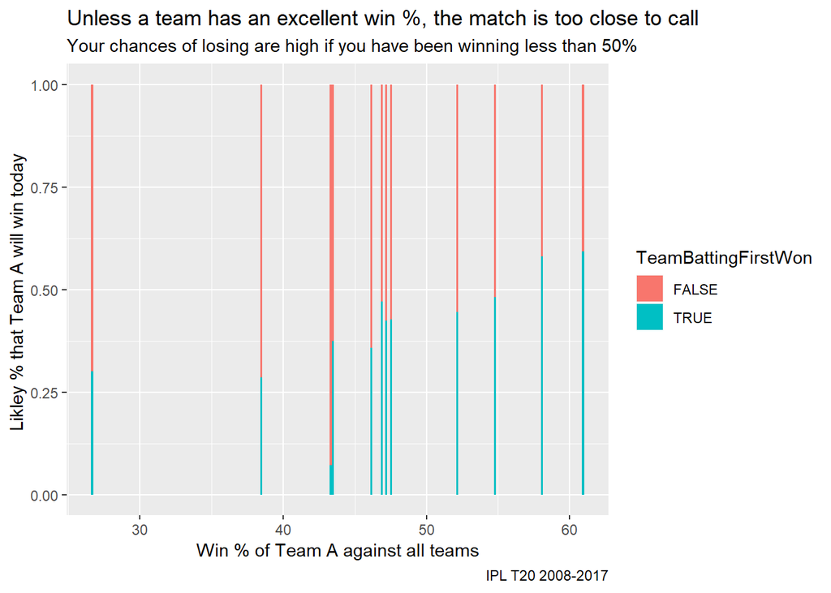

These plots show past results are a factor into today’s winning chances, but only if you have done very well, not just marginally well.

2b. Now let’s plot the final scores against runs scored and wickets lost during the match, specifically at the end of 6th, 10th and 15th overs; first effect of runs scored (continuous variable), and then wickets lost till those overs:

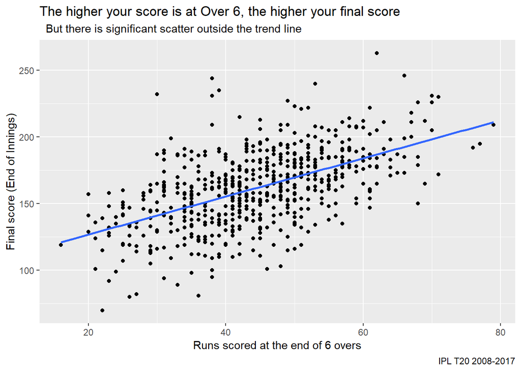

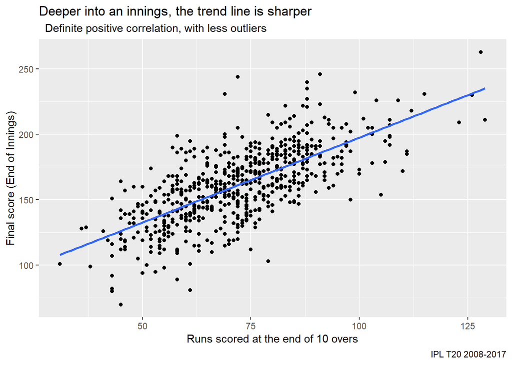

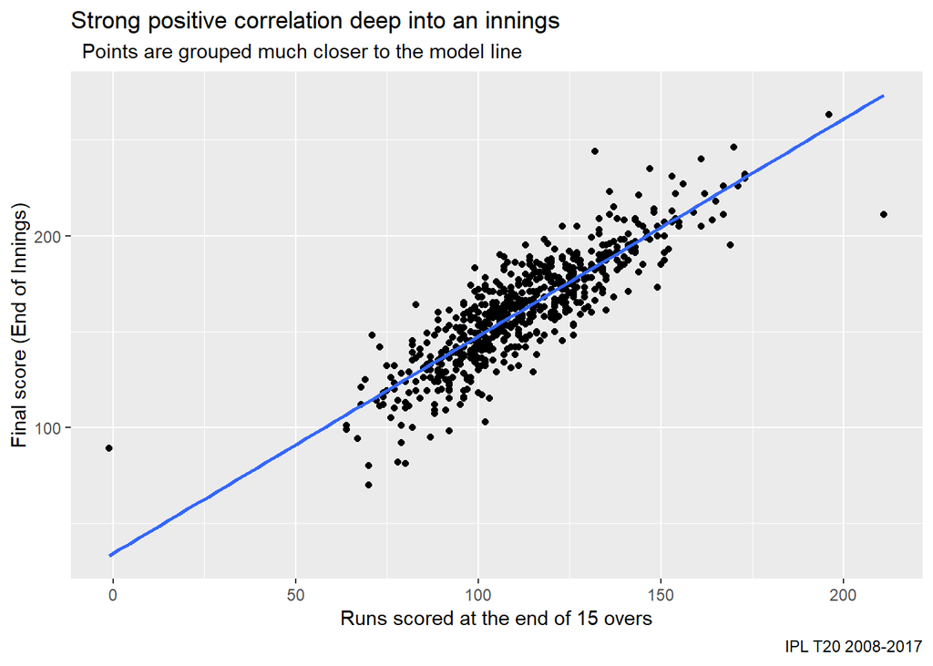

Finally let’s examine the plot for wickets lost at the end of 6th, 10th and 15th overs. We look at the covariation between 2 continuous variables by binning one of the 2 continuous variables (Wickets Lost):

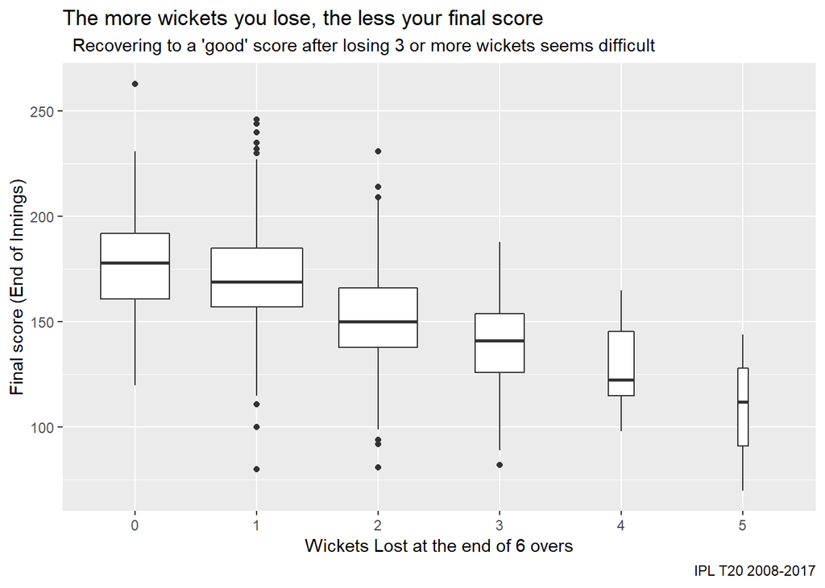

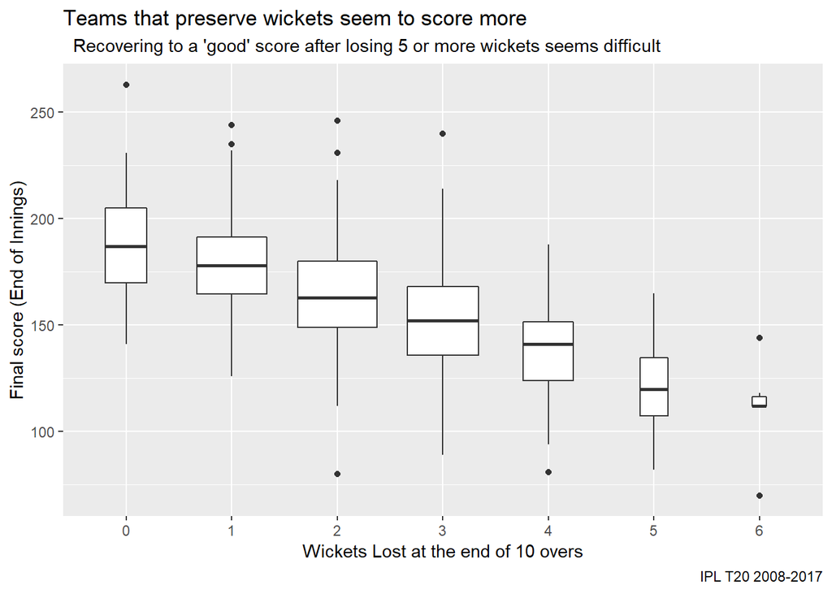

[figure not shown]

Based on the above sets of plots, *the best correlation of a team’s score seems to be the number of runs it scores in the current match and the fewer wickets it loses getting those runs in the early and mid overs*. These runs and wickets parameters will be used for building model prediction for end of innings score.